# U.S. Employment from 1940 - 2010

Jae Gnazzo

2/24/2022

### Data Source

#### https://datahub.io/core/employment-us

```r
# Adding in the data
emp <- read_csv("aat1_csv.csv")
```

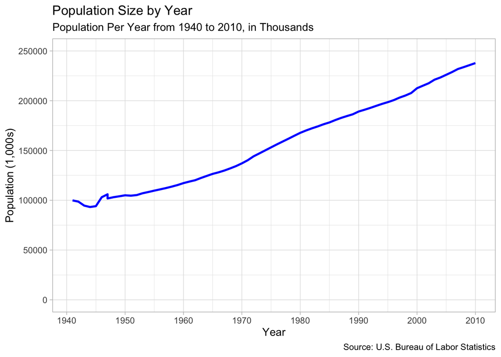

```r
emp %>%
  ggplot(mapping = aes(x = year, y = population, xmax = 2010, ymin = 0, ymax =250000)) +
  geom_line(color = 'blue', size = 1) +
  scale_x_continuous(breaks = c(1940, 1950, 1960, 1970, 1980, 1990, 2000, 2010)) +
  theme_light() +
  labs(title = "Population Size by Year",
       subtitle = "Population Per Year from 1940 to 2010, in Thousands",
       x = "Year",
       y = "Population (1,000s)",
       caption = "Source: U.S. Bureau of Labor Statistics")
```

### Visualization 1: Population Size by Year:

The above graph depicts the population size of the United States by year, from 1940 - 2010, in thousands of people. This was purposefully basic graph to view how population size has grown over time, and demonstrates the scope of the U.S. Bureau of Labor Statistics dataset we are working with. We also are able to identify that there were not any missing years, and that the U.S.’s population size has grown relatively linearly over the time period.

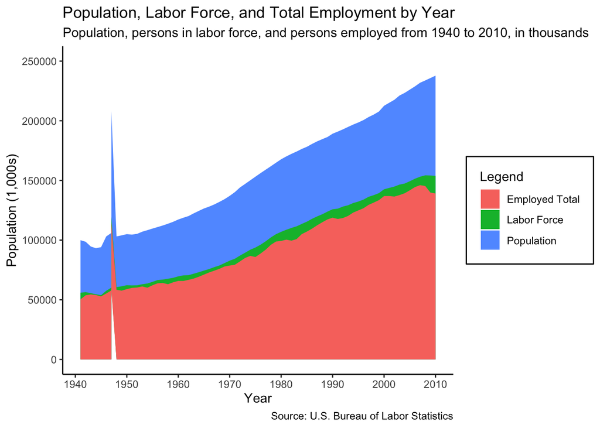

```r
plotting <- c("Population" = 'red', "Labor Force" = 'blue', "Employed Total" = 'green')
emp %>%
  ggplot(mapping = aes(x = year))  +
  geom_area(aes(y = population, fill = 'Population', position = "stack")) +
  geom_area(aes(y = labor_force, fill = 'Labor Force', position = "stack")) +
  geom_area(aes(y = employed_total, fill = 'Employed Total', position = "stack")) +
  scale_x_continuous(breaks = c(1940, 1950, 1960, 1970, 1980, 1990, 2000, 2010)) +
  scale_y_continuous(limits = c(0, 250000)) +
  theme_classic() +
  labs(title = "Population, Labor Force, and Total Employment by Year",
       subtitle = "Population, persons in labor force, and persons employed from 1940 to 2010, in thousands",
       x = "Year",
       y = "Population (1,000s)",
       fill = "Legend",
       caption = "Source: U.S. Bureau of Labor Statistics") +
  theme(
    legend.box.background = element_rect(color = "black", size = 0.5),
    legend.box.margin = margin(6, 6, 6, 6)
  )
```

The second visualization, population size by year, displays the population, persons in labor force, and person employed, from 1940 to 2010 in thousands of persons. This graphic uses the prior metric of population size to illustrate both the portion of the population that was in the labor force, and the portion of the population that was employed over the time series. We can see that labor force size and the total employment remain relatively consistent in growth compared to the population size over the long run. However, there is a notable dip in the total number of people employed starting in the year 2008, which coincides with the financial crisis.

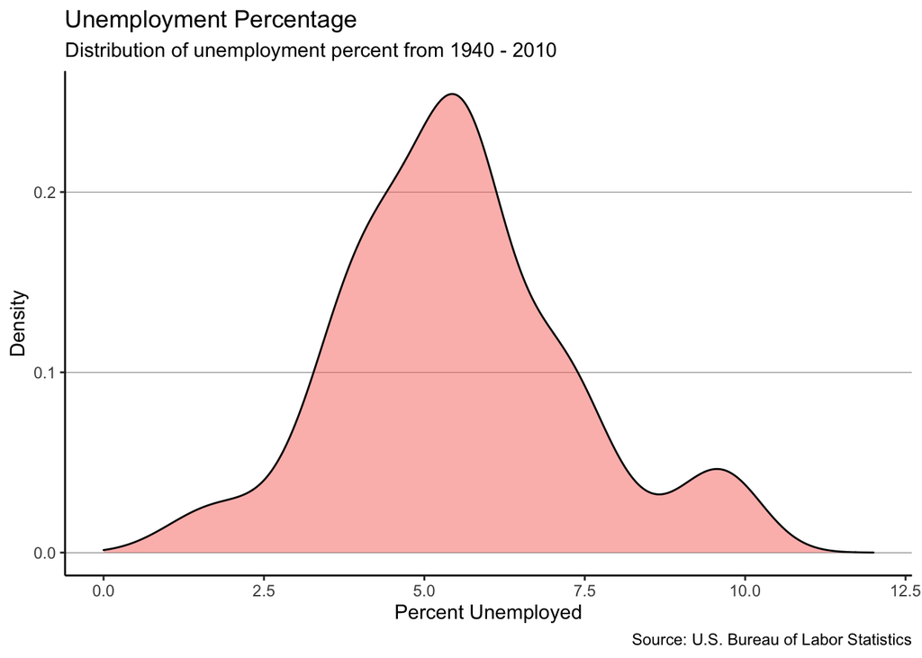

```r
emp %>%
  ggplot(mapping = aes(x = unemployed_percent, fill = "pink", xmin = 0, xmax = 12)) +
  geom_density(color = 'black', alpha = 0.5) +
  scale_x_continuous() +
  theme_classic() +
  theme(
    panel.grid.major.x = element_blank(),
    panel.grid.major.y = element_line(size = .1, color = "black")
  ) +
  theme(legend.position = "none") +
  labs(title = "Unemployment Percentage",
       subtitle = "Distribution of unemployment percent from 1940 - 2010",
       x = "Percent Unemployed",
       y = "Density",
       caption = "Source: U.S. Bureau of Labor Statistics")
```

### Visualization 3: Unemployment Percentage:

Our third visualization, unemployment percentage, displays the distribution of unemployment percentage from 1940 - 2010. The above plot visualizes the distribution of unemployment percentage over the entire time period. As we can see, the data has a high density at a bit above the 5% unemployment percentage, with lower distributions on either side. This indicates that over the course of the time series, most years average around a 5% to 6% unemployment rate. However, there is a slight increase in density at around 9%, indicating that a number of years exhibited higher than average unemployment rates.

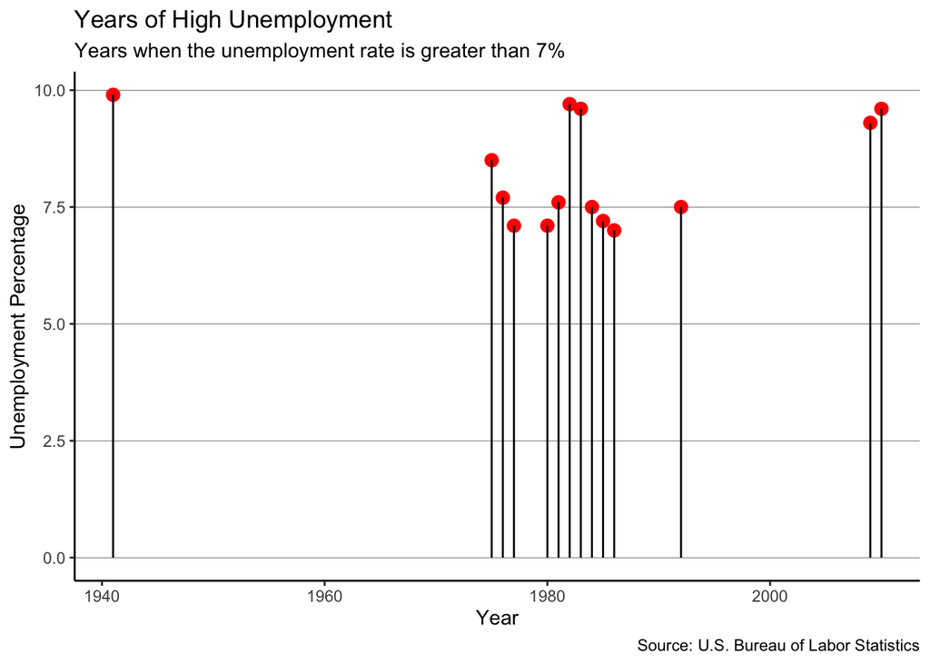

```r
emp_rest <- filter(emp, unemployed_percent >= 7)

emp_rest %>%
  ggplot(aes(x = year, y =unemployed_percent)) +
  geom_point(size = 3, color = "red") +
  geom_segment(aes(x = year, xend = year, y =0, yend = unemployed_percent), ) +
  scale_x_continuous() +
  scale_y_continuous() +
  theme_classic() +
  theme(
    panel.grid.major.x = element_blank(),
    panel.grid.major.y = element_line(size = .1, color = "black")
  ) +
  labs(title = "Years of High Unemployment",
       subtitle = "Years when the unemployment rate is greater than 7%",
       x = "Year",
       y = "Unemployment Percentage",
       caption = "Source: U.S. Bureau of Labor Statistics")
```